# Piecewsise functions - Library usage

This notebook is a simple walkthrough of this library and what you can do with it

## Features

The source code is located under `src/PiecewiseFunctions`. You'll find two piecewise functions implemented:

1. A piecewise constant function, `PiecewiseConstantFunction` Defined by the equation $y = b$ over a domain $D = [c,d]$ where $(b,c,d) \in \mathbb{R}^3$, where we have multiple definition domain $D$ (defined by the `breakpoints` in the proposed implementations)
2. A piecewise linear function, `PiecewiseLinearFunction` Defined by the equation $y = a*x + b$ over a domain $D = [c,d]$ where $(a,b,c,d) \in \mathbb{R}^4$, where we have multiple definition domain $D$ (defined by the `breakpoints` in the proposed implementations)

Both inherit from the `PiecewiseFunction` abstract class.

Every implementation of a piecewise function implements the 3 following methods:

- **Evaluate**

```
def evaluate(self, x: float) -> float:
    """ Return the value of the function on the given value if defined, otherwise raise a ValueError """
    pass
```

- **Maximum**

```
def maximum(self) -> float:
    """ Return the maximum value of the function over its definition domain """
    pass
```

- **Minimum**

```
def maximum(self) -> float:
    """ Return the minimum value of the function over its definition domain """
    pass
```

## `PiecewiseConstantFunction`

```python
# Imports - path for local test in this project
from src.PiecewiseFunctions.PiecewiseConstantFunction import PiecewiseConstantFunction
from src.PiecewiseFunctions.PiecewiseLinearFunction import PiecewiseLinearFunction

# You can install the library by running
# pip install -i https://test.pypi.org/simple/ --no-deps piecewise-functions-fp==0.0.5
# And then import it in your project like so:
# from PiecewiseFunctions.PiecewiseLinearFunction import PiecewiseLinearFunction

from src.PiecewiseFunctions.utils import draw
```

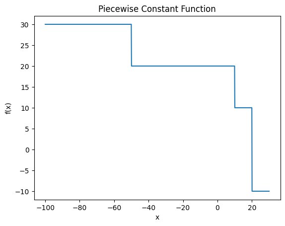

```python
piecewise_fn = PiecewiseConstantFunction(
        breakpoints=[-100.00, -50, 10, 20, 31.0],
        values=[30, 20, 10, -10]
    )
draw(
    piecewise_fn,
    x_min=-100,
    x_max=30,
    num_points=1000,
    title="Piecewise Constant Function",
)
```

The domains of definitions are pairs of borders in the `breakpoints` list `[-100.00, -50, 10, 20, 31.0]`, and the constants over those domaines are in the `values` list `[30, 20, 10, -10]`.

Note that the function is not defined in 31.

#### Minimum & maximum

To request the min, (resp. max) value and the $arg_{min}$ (resp. $arg_{max}$) value, use the `minimum()` method (resp. `maximum()`).

```python
min_value, arg_min = piecewise_fn.minimum()
max_value, arg_max = piecewise_fn.maximum()
print(f"Min value = {min_value} obtained at arg_min = {arg_min} for the Piecewise Constant Function")
print(f"Max value = {max_value} obtained at arg_max = {arg_max} for the Piecewise Constant Function")
```

```
Min value = -10 obtained at arg_min = 20 for the Piecewise Constant Function
Max value = 30 obtained at arg_max = -100.0 for the Piecewise Constant Function
```

#### Evaluate

You can obtain the value of the function on any domain it is defined by running the evaluate function.

```python
arg = -50
val = piecewise_fn.evaluate(arg)
print(f"Value = {val} obtained at arg = {arg} for the Piecewise Constant Function")
```

```
Value = 20 obtained at arg = -50 for the Piecewise Constant Function
```

## `PiecewiseLinearFunction`

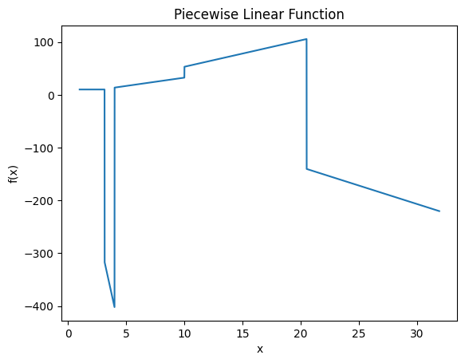

```python
import math

breakpoints = [1, math.pi, 4, 10, 20.5, 32]
slopes = [0, -100.02, math.pi, 5, -7]
intercepts = [10, -2, 1, 3, math.pi]
piecewise_linear_fn = PiecewiseLinearFunction(breakpoints, slopes, intercepts)
draw(
    piecewise_linear_fn,
    x_min=1,
    x_max=31.9,
    num_points=10000,
    title="Piecewise Linear Function",
)
```

The function call wan be understood this way: We have a function whose value is defined as so: $$

The domains of definitions are pairs of borders in the `breakpoints` list `[1, math.pi, 4, 10, 20.5, 32]`, and the slopes over those domaines are in the `slopes` list `[0, -100.02, math.pi, 5, -7]`, finally the `intercepts` list contains the constant `[10, -2, 1, 3, math.pi]`.

Note that the function is not defined in 32.

#### Minimum & maximum

You can obtain the (min_value, arg_min) and (max_value, arg_max) similarly as for the `PiecewiseConstantFunction`

```python
min_value_plf, arg_min_plf = piecewise_linear_fn.minimum()
max_value_plf, arg_max_plf = piecewise_linear_fn.maximum()
print(f"Min value = {min_value_plf} obtained at arg_min = {arg_min_plf} for the Piecewise Linear Function")
print(f"Max value = {max_value_plf} obtained at arg_max = {arg_max_plf} for the Piecewise Linear Function")
```

```
Min value = -402.08 obtained at arg_min = 4 for the Piecewise Linear Function
Max value = 105.5 obtained at arg_max = 20.5 for the Piecewise Linear Function
```

#### Evaluate

You can obtain the value of the function on any domain it is defined by running the evaluate function.

```python
arg = 2
val = piecewise_linear_fn.evaluate(arg)
print(f"Value = {val} obtained at arg = {arg} for the Piecewise Linear Function")
```

```
Value = 10 obtained at arg = 2 for the Piecewise Linear Function
```

# Benchmarks

Runtime evolution for `PiecewiseConstantFunction`

```python
from typing import Tuple, Dict
import random
import time

def large_input_pcf() -> Dict[int, Tuple[int, int, int]]:
    """
    Returns: dict of triplet.
        For each entry:
            - the key is the number of points we consider,
            - the value (u, v, w) is a triplet of time (in seconds) to perform an evaluation, to get the max and the min

    """
    scenarios_num_points = [10, 100, 1000, 10000, 100000, 1000000, 10000000]
    res = dict()
    for num_points in scenarios_num_points:
        breakpoints = (
            [-math.inf]
            + sorted([random.uniform(-1e6, 1e6) for _ in range(num_points)])
            + [math.inf]
        )
        values = [random.uniform(-1e6, 1e6) for _ in range(num_points + 1)]

        # Create a piecewise constant function with these breakpoints and values
        pcf = PiecewiseConstantFunction(breakpoints, values)

        # Time the maximum method
        start_time = time.time()
        pcf.maximum()
        end_time = time.time()
        get_max_time = end_time - start_time

        # Time the minimum method
        start_time = time.time()
        pcf.minimum()
        end_time = time.time()
        get_min_time = end_time - start_time

        # Time the evaluate method
        start_time = time.time()
        pcf.evaluate(0)
        end_time = time.time()
        get_eval_time = end_time - start_time

        res[num_points] = (get_eval_time, get_max_time, get_min_time)

    return  res
```

```python
# Get the benchmark for PCF
metrics_pcf : dict = large_input_pcf()
```

```python
metrics_pcf
```

```
{10: (2.1457672119140625e-06, 9.5367431640625e-07, 9.5367431640625e-07),
 100: (5.245208740234375e-06, 2.1457672119140625e-06, 1.9073486328125e-06),
 1000: (4.458427429199219e-05, 9.059906005859375e-06, 1.0251998901367188e-05),
 10000: (0.000537872314453125, 0.00014400482177734375, 0.00013589859008789062),
 100000: (0.004914999008178711, 0.0011022090911865234, 0.000949859619140625),
 1000000: (0.04903912544250488, 0.012611150741577148, 0.012550830841064453),
 10000000: (0.7065370082855225, 0.13796281814575195, 0.10538792610168457)}
```

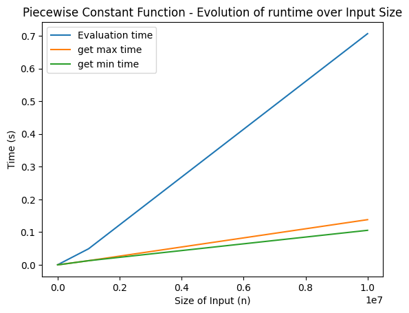

```python
import matplotlib.pyplot as plt

# Extract the times for each metric
time_eval = [t[0] for t in metrics_pcf.values()]
time_max = [t[1] for t in metrics_pcf.values()]
time_min = [t[2] for t in metrics_pcf.values()]

# Plot the times for each metric over the size of the input n
plt.plot(metrics_pcf.keys(), time_eval, label='Evaluation time')
plt.plot(metrics_pcf.keys(), time_max, label='get max time')
plt.plot(metrics_pcf.keys(), time_min, label='get min time')
plt.xlabel('Size of Input (n)')
plt.ylabel('Time (s)')
plt.title('Piecewise Constant Function - Evolution of runtime over Input Size')
plt.legend()
plt.show()
```

We observe that our function is linear in its runtime complexity which is coherent with a big O analysis showing runtime of $O(n)$ for n being the number of borders in our input.

### Runtime evolution for `PiecewiseLinearFunction`

```python
def large_input_plf() -> Dict[int, Tuple[int, int, int]]:
    """
    Returns: dict of triplet.
        For each entry:
            - the key is the number of points we consider,
            - the value (u, v, w) is a triplet of time (in seconds) to perform an evaluation, to get the max and the min

    """
    scenarios_num_points = [10, 100, 1000, 10000, 100000, 1000000, 10000000]
    res = dict()
    for num_points in scenarios_num_points:
        breakpoints = (
            [-math.inf]
            + sorted([random.uniform(-1e6, 1e6) for _ in range(num_points)])
            + [math.inf]
        )
        slopes = [random.uniform(-1e6, 1e6) for _ in range(num_points + 1)]
        intercepts = [random.uniform(-1e6, 1e6) for _ in range(num_points + 1)]

        # Create a piecewise constant function with these breakpoints and values
        plf = PiecewiseLinearFunction(breakpoints, slopes, intercepts)

        # Time the maximum method
        start_time = time.time()
        plf.maximum()
        end_time = time.time()
        get_max_time = end_time - start_time

        # Time the minimum method
        start_time = time.time()
        plf.minimum()
        end_time = time.time()
        get_min_time = end_time - start_time

        # Time the evaluate method
        start_time = time.time()
        plf.evaluate(0)
        end_time = time.time()
        get_eval_time = end_time - start_time

        res[num_points] = (get_eval_time, get_max_time, get_min_time)

    return  res
```

```python
# Get the benchmark for PLF
metrics_plf : dict = large_input_plf()
metrics_plf
```

```
{10: (1.6689300537109375e-06, 4.0531158447265625e-06, 4.0531158447265625e-06),
 100: (5.245208740234375e-06, 2.3126602172851562e-05, 2.193450927734375e-05),
 1000: (4.6253204345703125e-05, 0.00022912025451660156, 0.0002276897430419922),
 10000: (0.0005779266357421875, 0.002474069595336914, 0.002582073211669922),
 100000: (0.004950761795043945, 0.024026870727539062, 0.024761199951171875),
 1000000: (0.052500009536743164, 0.24958586692810059, 0.24257898330688477),
 10000000: (0.6834609508514404, 2.559155225753784, 2.5998380184173584)}
```

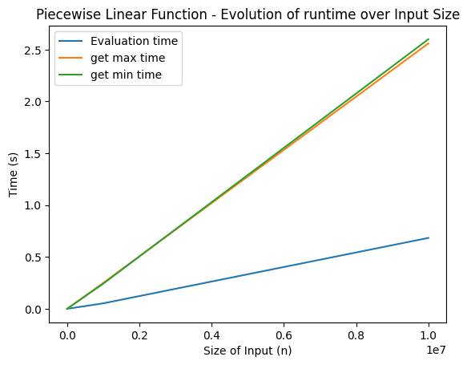

```python
# Extract the times for each metric
time_eval_plf = [t[0] for t in metrics_plf.values()]
time_max_plf = [t[1] for t in metrics_plf.values()]
time_min_plf = [t[2] for t in metrics_plf.values()]

# Plot the times for each metric over the size of the input n
plt.plot(metrics_plf.keys(), time_eval_plf, label='Evaluation time')
plt.plot(metrics_plf.keys(), time_max_plf, label='get max time')
plt.plot(metrics_plf.keys(), time_min_plf, label='get min time')
plt.xlabel('Size of Input (n)')
plt.ylabel('Time (s)')
plt.title('Piecewise Linear Function - Evolution of runtime over Input Size')
plt.legend()
plt.show()
```

We observe that our function is linear in its runtime complexity which is coherent with a big O analysis showing runtime of $O(n)$ for n being the number of borders in our input. The longer runtime for both get max and get min methods is expected because we do more operation of checking for conditions than our evaluation which is straightforward. If they have all the same $O(n)$ asymptotic runtime complexity, the evaluation method requires less operation in practice.